# Probabilidades

Lista avaliativa 2 – Probabilidade e Estatística – 2023.1

fnaufel

(v. 27/05/2023)

# 1 Cães e gatos

A média de despesas veterinárias com um cachorro é $$500$, com desvio-padrão de $$150$.

A média de despesas veterinárias com um gato é $$600$, com desvio-padrão de $$175$.

1. Qual o valor esperado da diferença entre as despesas veterinárias com um cachorro e com um gato?
2. Qual é o desvio padrão dessa diferença?
3. Se as distribuições dos dois tipos de despesas forem normais, qual é a probabilidade de que as despesas veterinárias com um cachorro sejam maiores do que as despesas veterinárias com um gato?

Mostre seu raciocínio detalhado.

# 2 Basquete

Um jogador costuma acertar $60\%$ dos seus lances livres.

Supondo que os lances livres são independentes entre si, qual é a probabilidade de que, no próximo jogo,

1. Ele erre pela primeira vez no quinto lance livre?
2. Ele acerte pela primeira vez no quarto lance livre?
3. Ele acerte pelo menos um dos primeiros $3$ lances livres?

Mostre seu raciocínio detalhado e use R para calcular as respostas.

# 3 Bolas

Numa fábrica de bolas, um gerente registra a quantidade de bolas defeituosas na produção de cada dia.

Ele nota que

- A quantidade de bolas defeituosas por dia é pequena;
- A qualidade da produção de um dia não influencia a qualidade da produção do dia seguinte.

Responda:

1. Qual distribuição de probabilidade você deve usar para modelar o número de bolas defeituosas por dia? Por quê?
2. Você fez alguma suposição adicional, além do que foi dito no enunciado? Qual(is)?
3. Se a média de bolas defeituosas por dia é $4{,}6$, qual a probabilidade de que nenhuma bola defeituosa seja produzida amanhã?
4. Se a média de bolas defeituosas por dia é $4{,}6$, qual a probabilidade de que $6$ ou mais bolas defeituosas sejam produzidas amanhã?

Mostre seu raciocínio detalhado e use R para calcular as respostas.

# 4 Colesterol

Considere que o nível de colesterol na população de mulheres adultas é distribuído normalmente, com média de $196$mg/dL e desvio-padrão de $27$mg/dL.

1. Faça o gráfico desta distribuição.
2. Qual percentagem das mulheres tem níveis acima de $200$mg/dL?
3. Qual percentagem das mulheres tem níveis entre $170$mg/dL e $180$mg/dL?
4. Qual o valor acima do qual estão os $15\%$ das mulheres com os níveis mais altos?

Mostre seu raciocínio detalhado e use R para calcular as respostas.

# 5 Pessoas canhotas

Considere que $12\%$ da população é canhota.

De $100$ pessoas escolhidas independentemente, ao acaso, com probabilidade uniforme, qual é a probabilidade de

1. A primeira pessoa canhota ser a $71$ª?
2. Haver alguma pessoa canhota entre as primeiras $50$?
3. Haver exatamente $12$ pessoas canhotas no grupo?
4. Haver pelo menos $20$ pessoas canhotas no grupo?
5. Não haver mais que $20$ pessoas canhotas no grupo?

Mostre seu raciocínio detalhado e use R para calcular as respostas.

# 6 Mega-sena (questão bônus, valendo 1 ponto)

Visite https://loterias.caixa.gov.br/Paginas/Mega-Sena.aspx e desça até a seção “Probabilidade”. Você verá a tabela

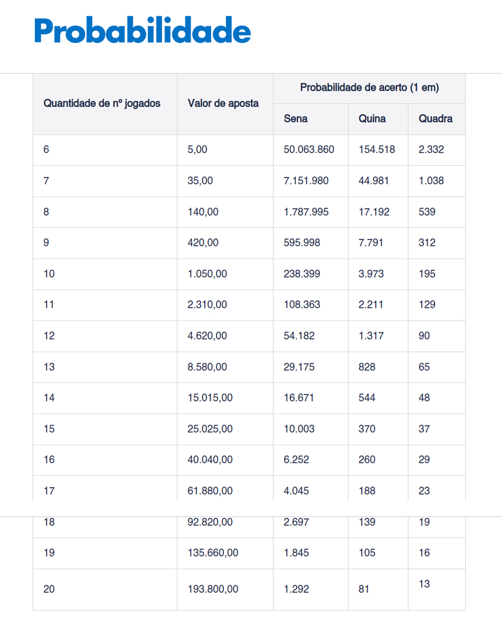

1. Explique em detalhes como a distribuição hipergeométrica é usada para calcular as probabilidades de acertar na sena.
2. Escreva código em R para reproduzir a tabela de probabilidades de acerto na sena.
3. Explique por que os preços das apostas são justos.

   Mais especificamente, um jogo de $7$ números tem a mesma probabilidade de acertar a sena que $7$ jogos de $6$ números.

   Por isso, o valor do jogo de $7$ números é $7$ vezes o valor de um jogo de $6$ números.
   1. Explique por que um jogo de $7$ números tem a mesma probabilidade de acertar a sena que $7$ jogos de $6$ números.
   2. Para $n \in \{8, 9, 10, \ldots, 20 \}$, escreva código em R para responder à pergunta

      Um jogo de $n$ números equivale a quantos jogos de $6$ números?